# Superciclo Classic ML

CebaData / Los Vochos — fase 2. CV leave-one-municipio-out. Semilla 20261006.

**Cómo leer este informe**

- **RMSE / MAE** (errores en t/ha): **menor es mejor** (ideal cerca de 0).
- **r²**: **mayor es mejor** (1 = perfecto; 0 ≈ predecir la media; negativo = peor que la media).
- **Baselines** (media global / por estado): un buen modelo debe tener RMSE **claramente menor**.
- **Real vs predicho**: cuanto más cerca de la diagonal, mejor.
- **Residuos** (predicho − real): ideal centrados en 0; positivo = sobreestima; negativo = subestima.
- En tablas, las columnas con ↓ indican “menor mejor”; ↑ indican “mayor mejor”.

## Resumen ejecutivo

Classic suficiente para entrega

HPO mejoró solo 0.0088 RMSE (<0.02); mejor B ya bate baseline estado por 0.542.

- Baseline media global RMSE (menor mejor): **1.1530**
- Baseline media estado RMSE (menor mejor): **1.0838**
- Mejor capa B: `parcelas_solo2025_ubic_mun-lon_n-edaf_v1` / `lightgbm` → RMSE **0.5417** (menor mejor)
- Mejor capa C (HPO): `parcelas_solo2025_ubic_lon-pix_n-edaf_v1` / `lightgbm` → RMSE **0.5329** (Δ HPO=0.0088; mejora = RMSE más bajo)
- Chequeo píxel (RMSE agregado, menor mejor): 0.5328587015246019

## Rankings

### Top-20 capa B (defaults)

Ordenados por RMSE ascendente: el primero es el mejor (menor error).

| dataset_id | modelo | temporal | ubic_tag | ext_tag | RMSE ↓ (menor mejor) | MAE ↓ (menor mejor) | r² ↑ (mayor mejor) | Disp. folds (menor = más estable) | hparams_id | capa |
| --- | --- | --- | --- | --- | --- | --- | --- | --- | --- | --- |
| parcelas_solo2025_ubic_mun-lon_n-edaf_v1 | lightgbm | solo2025 | ubic_mun-lon | n-edaf | 0.5417 | 0.3795 | 0.5920 | 0.2710 | default | B |
| parcelas_solo2025_ubic_lon-pix_n-edaf_v1 | lightgbm | solo2025 | ubic_lon-pix | n-edaf | 0.5431 | 0.3826 | 0.5900 | 0.2756 | default | B |
| parcelas_solo2025_ubic_lon_n_v1 | lightgbm | solo2025 | ubic_lon | n | 0.5432 | 0.3843 | 0.5897 | 0.2651 | default | B |
| parcelas_solo2025_ubic_lon_n-edaf_v1 | lightgbm | solo2025 | ubic_lon | n-edaf | 0.5444 | 0.3839 | 0.5879 | 0.2690 | default | B |
| parcelas_solo2025_ubic_mun-lon-pix_n-edaf_v1 | lightgbm | solo2025 | ubic_mun-lon-pix | n-edaf | 0.5449 | 0.3831 | 0.5871 | 0.2694 | default | B |
| parcelas_solo2025_ubic_lon-pix_n_v1 | lightgbm | solo2025 | ubic_lon-pix | n | 0.5453 | 0.3851 | 0.5866 | 0.2608 | default | B |
| parcelas_solo2025_ubic_lon_n-edaf-silt_v1 | lightgbm | solo2025 | ubic_lon | n-edaf-silt | 0.5460 | 0.3815 | 0.5854 | 0.2797 | default | B |
| parcelas_solo2025_ubic_lon-pix_n-edaf-silt_v1 | lightgbm | solo2025 | ubic_lon-pix | n-edaf-silt | 0.5462 | 0.3789 | 0.5853 | 0.2876 | default | B |
| parcelas_solo2025_ubic_mun-lon_n-edaf-silt_v1 | lightgbm | solo2025 | ubic_mun-lon | n-edaf-silt | 0.5464 | 0.3818 | 0.5849 | 0.2851 | default | B |
| parcelas_solo2025_ubic_mun-lon_n-silt_v1 | lightgbm | solo2025 | ubic_mun-lon | n-silt | 0.5475 | 0.3832 | 0.5832 | 0.2896 | default | B |
| parcelas_solo2025_ubic_lon-pix_n-silt_v1 | lightgbm | solo2025 | ubic_lon-pix | n-silt | 0.5477 | 0.3865 | 0.5829 | 0.2803 | default | B |
| parcelas_solo2025_ubic_mun-lon-pix_n-silt_v1 | lightgbm | solo2025 | ubic_mun-lon-pix | n-silt | 0.5480 | 0.3831 | 0.5824 | 0.2780 | default | B |
| parcelas_solo2025_ubic_mun-lon_n_v1 | lightgbm | solo2025 | ubic_mun-lon | n | 0.5487 | 0.3909 | 0.5814 | 0.2727 | default | B |
| parcelas_solo2025_ubic_mun-lon-pix_n-edaf-silt_v1 | lightgbm | solo2025 | ubic_mun-lon-pix | n-edaf-silt | 0.5488 | 0.3851 | 0.5813 | 0.2738 | default | B |
| parcelas_solo2025_ubic_lon-pix_edaf_v1 | lightgbm | solo2025 | ubic_lon-pix | edaf | 0.5497 | 0.3845 | 0.5798 | 0.3143 | default | B |
| parcelas_solo2025_ubic_lon_reto_v1 | lightgbm | solo2025 | ubic_lon | reto | 0.5499 | 0.3855 | 0.5796 | 0.3356 | default | B |
| parcelas_solo2025_ubic_mun-lon-pix_n_v1 | lightgbm | solo2025 | ubic_mun-lon-pix | n | 0.5499 | 0.3928 | 0.5796 | 0.2611 | default | B |
| parcelas_solo2025_ubic_lon_edaf_v1 | lightgbm | solo2025 | ubic_lon | edaf | 0.5501 | 0.3840 | 0.5793 | 0.3033 | default | B |
| parcelas_solo2025_ubic_lon_n-cec-silt_v1 | lightgbm | solo2025 | ubic_lon | n-cec-silt | 0.5502 | 0.3877 | 0.5792 | 0.2929 | default | B |
| parcelas_solo2025_ubic_lon-pix_n-cec-silt_v1 | lightgbm | solo2025 | ubic_lon-pix | n-cec-silt | 0.5504 | 0.3895 | 0.5787 | 0.2861 | default | B |

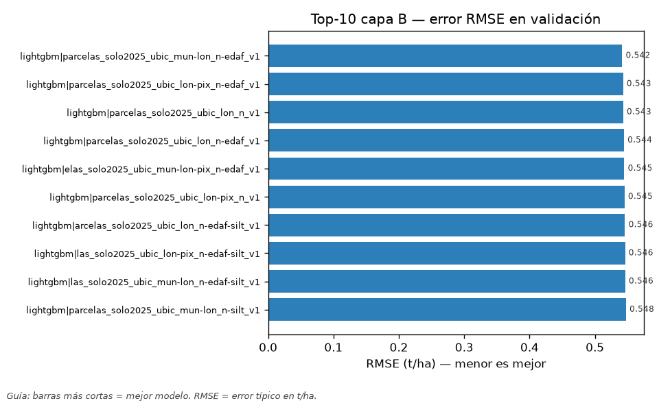

Barras más cortas = mejor. RMSE en t/ha; menor es mejor.

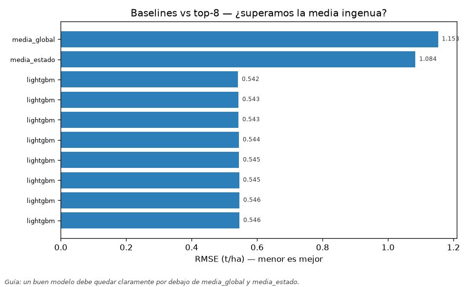

Comparar con baselines: el modelo útil queda claramente por debajo de las medias ingenuas.

### Top-20 capa C (HPO)

Hiperparámetros afinados. Sigue valiendo: menor RMSE = mejor.

| dataset_id | modelo | temporal | ubic_tag | ext_tag | RMSE ↓ (menor mejor) | MAE ↓ (menor mejor) | r² ↑ (mayor mejor) | Disp. folds (menor = más estable) | hparams_id | capa |
| --- | --- | --- | --- | --- | --- | --- | --- | --- | --- | --- |
| parcelas_solo2025_ubic_lon-pix_n-edaf_v1 | lightgbm | solo2025 | ubic_lon-pix | n-edaf | 0.5329 | 0.3695 | 0.6052 | 0.2965 | {"learning_rate": 0.03, "min_child_samples": 10, "num_leaves": 31} | C |
| parcelas_solo2025_ubic_lon-pix_n-edaf_v1 | lightgbm | solo2025 | ubic_lon-pix | n-edaf | 0.5329 | 0.3695 | 0.6052 | 0.2965 | {"learning_rate": 0.03, "min_child_samples": 10, "num_leaves": 15} | C |
| parcelas_solo2025_ubic_lon_n-edaf_v1 | lightgbm | solo2025 | ubic_lon | n-edaf | 0.5339 | 0.3696 | 0.6037 | 0.3129 | {"learning_rate": 0.03, "min_child_samples": 10, "num_leaves": 15} | C |
| parcelas_solo2025_ubic_lon_n-edaf_v1 | lightgbm | solo2025 | ubic_lon | n-edaf | 0.5339 | 0.3696 | 0.6037 | 0.3129 | {"learning_rate": 0.03, "min_child_samples": 10, "num_leaves": 31} | C |
| parcelas_solo2025_ubic_mun-lon-pix_n-edaf_v1 | lightgbm | solo2025 | ubic_mun-lon-pix | n-edaf | 0.5361 | 0.3709 | 0.6004 | 0.2896 | {"learning_rate": 0.03, "min_child_samples": 10, "num_leaves": 31} | C |
| parcelas_solo2025_ubic_mun-lon-pix_n-edaf_v1 | lightgbm | solo2025 | ubic_mun-lon-pix | n-edaf | 0.5361 | 0.3709 | 0.6004 | 0.2896 | {"learning_rate": 0.03, "min_child_samples": 10, "num_leaves": 15} | C |
| parcelas_solo2025_ubic_lon-pix_n-edaf-silt_v1 | lightgbm | solo2025 | ubic_lon-pix | n-edaf-silt | 0.5368 | 0.3778 | 0.5994 | 0.2843 | {"learning_rate": 0.03, "min_child_samples": 10, "num_leaves": 31} | C |
| parcelas_solo2025_ubic_lon-pix_n-edaf-silt_v1 | lightgbm | solo2025 | ubic_lon-pix | n-edaf-silt | 0.5368 | 0.3778 | 0.5994 | 0.2843 | {"learning_rate": 0.03, "min_child_samples": 10, "num_leaves": 15} | C |
| parcelas_solo2025_ubic_lon_n-edaf-silt_v1 | lightgbm | solo2025 | ubic_lon | n-edaf-silt | 0.5372 | 0.3788 | 0.5987 | 0.2866 | {"learning_rate": 0.03, "min_child_samples": 10, "num_leaves": 31} | C |
| parcelas_solo2025_ubic_lon_n-edaf-silt_v1 | lightgbm | solo2025 | ubic_lon | n-edaf-silt | 0.5372 | 0.3788 | 0.5987 | 0.2866 | {"learning_rate": 0.03, "min_child_samples": 10, "num_leaves": 15} | C |
| parcelas_solo2025_ubic_mun-lon-pix_n-silt_v1 | lightgbm | solo2025 | ubic_mun-lon-pix | n-silt | 0.5372 | 0.3784 | 0.5987 | 0.2821 | {"learning_rate": 0.03, "min_child_samples": 10, "num_leaves": 15} | C |
| parcelas_solo2025_ubic_mun-lon-pix_n-silt_v1 | lightgbm | solo2025 | ubic_mun-lon-pix | n-silt | 0.5372 | 0.3784 | 0.5987 | 0.2821 | {"learning_rate": 0.03, "min_child_samples": 10, "num_leaves": 31} | C |
| parcelas_solo2025_ubic_mun-lon_n-edaf_v1 | lightgbm | solo2025 | ubic_mun-lon | n-edaf | 0.5378 | 0.3725 | 0.5979 | 0.3161 | {"learning_rate": 0.03, "min_child_samples": 10, "num_leaves": 31} | C |
| parcelas_solo2025_ubic_mun-lon_n-edaf_v1 | lightgbm | solo2025 | ubic_mun-lon | n-edaf | 0.5378 | 0.3725 | 0.5979 | 0.3161 | {"learning_rate": 0.03, "min_child_samples": 10, "num_leaves": 15} | C |
| parcelas_solo2025_ubic_mun-lon_n-edaf-silt_v1 | lightgbm | solo2025 | ubic_mun-lon | n-edaf-silt | 0.5379 | 0.3782 | 0.5977 | 0.2806 | {"learning_rate": 0.03, "min_child_samples": 10, "num_leaves": 15} | C |
| parcelas_solo2025_ubic_mun-lon_n-edaf-silt_v1 | lightgbm | solo2025 | ubic_mun-lon | n-edaf-silt | 0.5379 | 0.3782 | 0.5977 | 0.2806 | {"learning_rate": 0.03, "min_child_samples": 10, "num_leaves": 31} | C |
| parcelas_solo2025_ubic_mun-lon_n-silt_v1 | lightgbm | solo2025 | ubic_mun-lon | n-silt | 0.5381 | 0.3785 | 0.5974 | 0.2970 | {"learning_rate": 0.03, "min_child_samples": 10, "num_leaves": 15} | C |
| parcelas_solo2025_ubic_mun-lon_n-silt_v1 | lightgbm | solo2025 | ubic_mun-lon | n-silt | 0.5381 | 0.3785 | 0.5974 | 0.2970 | {"learning_rate": 0.03, "min_child_samples": 10, "num_leaves": 31} | C |
| parcelas_solo2025_ubic_lon_n_v1 | lightgbm | solo2025 | ubic_lon | n | 0.5382 | 0.3745 | 0.5972 | 0.3095 | {"learning_rate": 0.03, "min_child_samples": 10, "num_leaves": 15} | C |
| parcelas_solo2025_ubic_lon_n_v1 | lightgbm | solo2025 | ubic_lon | n | 0.5382 | 0.3745 | 0.5972 | 0.3095 | {"learning_rate": 0.03, "min_child_samples": 10, "num_leaves": 31} | C |

### Solo reto vs extendido (capa B)

**Solo reto** — menor RMSE es mejor

| dataset_id | modelo | temporal | ubic_tag | ext_tag | RMSE ↓ (menor mejor) | MAE ↓ (menor mejor) | r² ↑ (mayor mejor) | Disp. folds (menor = más estable) | hparams_id | capa |
| --- | --- | --- | --- | --- | --- | --- | --- | --- | --- | --- |
| parcelas_solo2025_ubic_lon_reto_v1 | lightgbm | solo2025 | ubic_lon | reto | 0.5499 | 0.3855 | 0.5796 | 0.3356 | default | B |
| parcelas_solo2025_ubic_lon-pix_reto_v1 | lightgbm | solo2025 | ubic_lon-pix | reto | 0.5508 | 0.3873 | 0.5781 | 0.3172 | default | B |
| parcelas_solo2025_ubic_mun-lon_reto_v1 | lightgbm | solo2025 | ubic_mun-lon | reto | 0.5558 | 0.3927 | 0.5705 | 0.3389 | default | B |
| parcelas_solo2025_ubic_mun-lon-pix_reto_v1 | lightgbm | solo2025 | ubic_mun-lon-pix | reto | 0.5562 | 0.3925 | 0.5699 | 0.3105 | default | B |
| parcelas_solo2025_ubic_est-lon-pix_reto_v1 | lightgbm | solo2025 | ubic_est-lon-pix | reto | 0.5815 | 0.4177 | 0.5298 | 0.3337 | default | B |
| parcelas_solo2025_ubic_est-mun-lon-pix_reto_v1 | lightgbm | solo2025 | ubic_est-mun-lon-pix | reto | 0.5821 | 0.4176 | 0.5289 | 0.3376 | default | B |
| parcelas_solo2025_ubic_est-lon_reto_v1 | lightgbm | solo2025 | ubic_est-lon | reto | 0.5828 | 0.4188 | 0.5277 | 0.3341 | default | B |
| parcelas_solo2025_ubic_est-mun-lon_reto_v1 | lightgbm | solo2025 | ubic_est-mun-lon | reto | 0.5830 | 0.4191 | 0.5274 | 0.3356 | default | B |
| parcelas_multianio_ubic_lon-pix_reto_v1 | lightgbm | multianio | ubic_lon-pix | reto | 0.5923 | 0.4471 | 0.5122 | 0.4308 | default | B |
| parcelas_multianio_ubic_mun-lon-pix_reto_v1 | lightgbm | multianio | ubic_mun-lon-pix | reto | 0.5923 | 0.4464 | 0.5122 | 0.4301 | default | B |
| parcelas_multianio_ubic_lon_reto_v1 | lightgbm | multianio | ubic_lon | reto | 0.5925 | 0.4473 | 0.5119 | 0.4336 | default | B |
| parcelas_multianio_ubic_mun-lon_reto_v1 | lightgbm | multianio | ubic_mun-lon | reto | 0.5932 | 0.4470 | 0.5107 | 0.4353 | default | B |
| parcelas_multianio_ubic_est-lon-pix_reto_v1 | lightgbm | multianio | ubic_est-lon-pix | reto | 0.5948 | 0.4462 | 0.5082 | 0.4299 | default | B |
| parcelas_multianio_ubic_est-mun-lon-pix_reto_v1 | lightgbm | multianio | ubic_est-mun-lon-pix | reto | 0.5948 | 0.4462 | 0.5082 | 0.4299 | default | B |
| parcelas_multianio_ubic_est-lon_reto_v1 | lightgbm | multianio | ubic_est-lon | reto | 0.5961 | 0.4471 | 0.5060 | 0.4351 | default | B |

**Extendido** — menor RMSE es mejor; si apenas baja respecto al reto, el externo aporta poco

| dataset_id | modelo | temporal | ubic_tag | ext_tag | RMSE ↓ (menor mejor) | MAE ↓ (menor mejor) | r² ↑ (mayor mejor) | Disp. folds (menor = más estable) | hparams_id | capa |
| --- | --- | --- | --- | --- | --- | --- | --- | --- | --- | --- |
| parcelas_solo2025_ubic_mun-lon_n-edaf_v1 | lightgbm | solo2025 | ubic_mun-lon | n-edaf | 0.5417 | 0.3795 | 0.5920 | 0.2710 | default | B |
| parcelas_solo2025_ubic_lon-pix_n-edaf_v1 | lightgbm | solo2025 | ubic_lon-pix | n-edaf | 0.5431 | 0.3826 | 0.5900 | 0.2756 | default | B |
| parcelas_solo2025_ubic_lon_n_v1 | lightgbm | solo2025 | ubic_lon | n | 0.5432 | 0.3843 | 0.5897 | 0.2651 | default | B |
| parcelas_solo2025_ubic_lon_n-edaf_v1 | lightgbm | solo2025 | ubic_lon | n-edaf | 0.5444 | 0.3839 | 0.5879 | 0.2690 | default | B |
| parcelas_solo2025_ubic_mun-lon-pix_n-edaf_v1 | lightgbm | solo2025 | ubic_mun-lon-pix | n-edaf | 0.5449 | 0.3831 | 0.5871 | 0.2694 | default | B |
| parcelas_solo2025_ubic_lon-pix_n_v1 | lightgbm | solo2025 | ubic_lon-pix | n | 0.5453 | 0.3851 | 0.5866 | 0.2608 | default | B |
| parcelas_solo2025_ubic_lon_n-edaf-silt_v1 | lightgbm | solo2025 | ubic_lon | n-edaf-silt | 0.5460 | 0.3815 | 0.5854 | 0.2797 | default | B |
| parcelas_solo2025_ubic_lon-pix_n-edaf-silt_v1 | lightgbm | solo2025 | ubic_lon-pix | n-edaf-silt | 0.5462 | 0.3789 | 0.5853 | 0.2876 | default | B |
| parcelas_solo2025_ubic_mun-lon_n-edaf-silt_v1 | lightgbm | solo2025 | ubic_mun-lon | n-edaf-silt | 0.5464 | 0.3818 | 0.5849 | 0.2851 | default | B |
| parcelas_solo2025_ubic_mun-lon_n-silt_v1 | lightgbm | solo2025 | ubic_mun-lon | n-silt | 0.5475 | 0.3832 | 0.5832 | 0.2896 | default | B |
| parcelas_solo2025_ubic_lon-pix_n-silt_v1 | lightgbm | solo2025 | ubic_lon-pix | n-silt | 0.5477 | 0.3865 | 0.5829 | 0.2803 | default | B |
| parcelas_solo2025_ubic_mun-lon-pix_n-silt_v1 | lightgbm | solo2025 | ubic_mun-lon-pix | n-silt | 0.5480 | 0.3831 | 0.5824 | 0.2780 | default | B |
| parcelas_solo2025_ubic_mun-lon_n_v1 | lightgbm | solo2025 | ubic_mun-lon | n | 0.5487 | 0.3909 | 0.5814 | 0.2727 | default | B |
| parcelas_solo2025_ubic_mun-lon-pix_n-edaf-silt_v1 | lightgbm | solo2025 | ubic_mun-lon-pix | n-edaf-silt | 0.5488 | 0.3851 | 0.5813 | 0.2738 | default | B |
| parcelas_solo2025_ubic_lon-pix_edaf_v1 | lightgbm | solo2025 | ubic_lon-pix | edaf | 0.5497 | 0.3845 | 0.5798 | 0.3143 | default | B |

## Ejes del catálogo

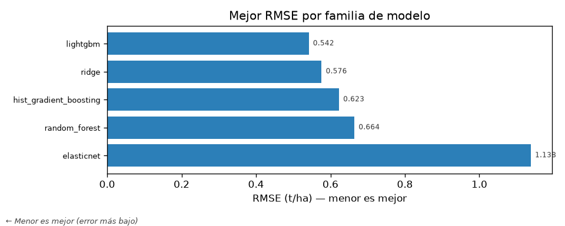

Menor RMSE = mejor familia en su mejor dataset.

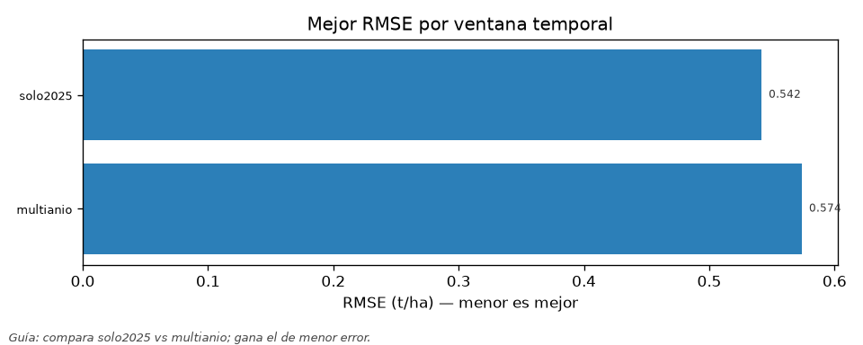

Menor RMSE = mejor ventana temporal.

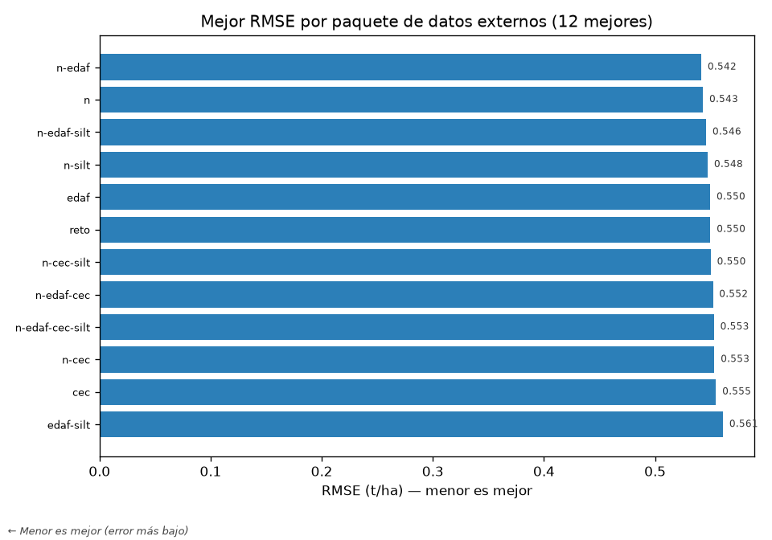

Menor RMSE = mejores paquetes de datos externos.

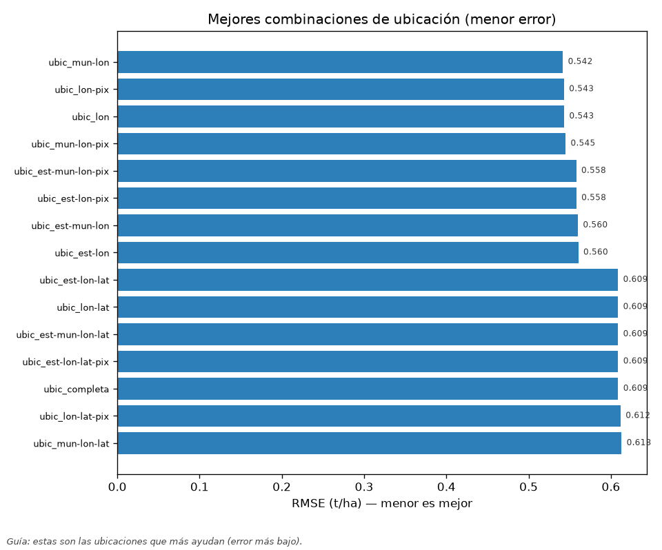

Menor RMSE = esquemas de ubicación más útiles.

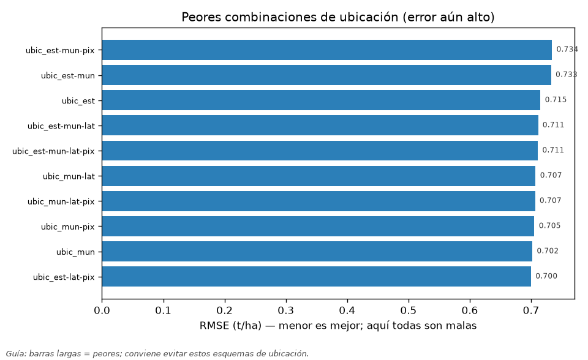

Barras largas = peores ubicaciones (evitar).

Dominancia top-50: {"modelo": {"lightgbm": 50}, "temporal": {"solo2025": 50}, "ext_tag": {"n-edaf-silt": 8, "n-edaf": 4, "n": 4, "n-silt": 4, "edaf": 4, "reto": 4, "n-cec-silt": 4, "n-edaf-cec": 4, "n-edaf-cec-silt": 4, "n-cec": 4}, "ubic_tag": {"ubic_lon": 13, "ubic_lon-pix": 12, "ubic_mun-lon": 11, "ubic_mun-lon-pix": 10, "ubic_est-mun-lon-pix": 1, "ubic_est-lon-pix": 1, "ubic_est-mun-lon": 1, "ubic_est-lon": 1}}

## Diagnósticos

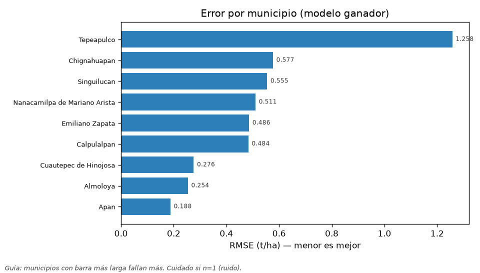

Menor RMSE por municipio = mejor. Municipios con n=1 son ruidosos.

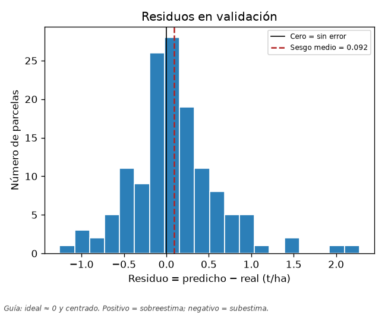

Ideal centrado en 0. Positivo = sobreestima; negativo = subestima. Sesgo cerca de 0 es mejor.

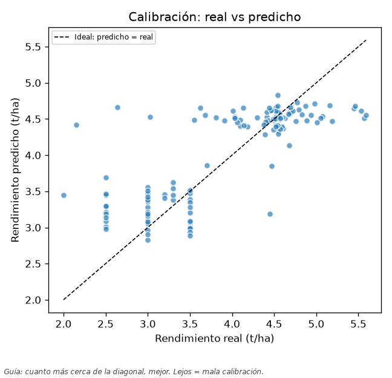

Cuanto más cerca de la diagonal, mejor calibración.

Residuo medio OOF (cerca de 0 es mejor): 0.09207701216810518; std: 0.526755045688275. Municipios con n=1: ['Tepeapulco', 'Nanacamilpa de Mariano Arista', 'Apan']

Límites: LOGO con municipios de 1 parcela hace r² por fold inestable; confiar en RMSE/MAE OOF globales. Selección entre 1024×modelos implica riesgo de sobreajuste al ranking.

## Recomendaciones

### Modelos

- No seguir tuneando hiperparámetros de la familia ganadora: HPO aportó solo 0.0088 RMSE (umbral 0.02).
- Árboles dominan el top-50 (lightgbm); no insistir en más alphas lineales.
- Veredicto Classic ML: **Classic suficiente para entrega** — HPO mejoró solo 0.0088 RMSE (<0.02); mejor B ya bate baseline estado por 0.542.

### Datasets / features

- CSV recomendado (ganador): `parcelas_solo2025_ubic_lon-pix_n-edaf_v1` con modelo `lightgbm`.
- Mejor solo-reto RMSE=0.5499; mejor extendido RMSE=0.5417050732009819. Gap reto−ext=0.00814880538439533.
- Gap reto/extendido < 0.02: entregar carril solo-reto salvo que el externo aporte trazabilidad.
- Dominancia temporal en top-50: {'solo2025': 50}.

### Predicción de las 59 y entrega

- Predecir las 59 con el ganador C (`modelos/salidas/superciclo_v1/prediccion_59_ganador.csv`).
- No versionar miles de joblibs; un artefacto en `entrega/` cuando el equipo firme.
- Municipios con peor RMSE OOF (confianza desigual): Tepeapulco (1.26), Chignahuapan (0.58), Singuilucan (0.55)

### Dashboard (fase 3)

- Entrada: fila(s) con columnas del CSV ganador (sin rendimiento) o ID ya curado.
- Salida: `rendimiento_pred_t_ha`, `modelo_id=lightgbm`, `dataset_id=parcelas_solo2025_ubic_lon-pix_n-edaf_v1`, banda opcional ±0.53 (RMSE OOF).
- UI MVP: lista/mapa de predicción → detalle parcela → panel ‘cómo se eligió’ (link a este HTML).
- Fuera de MVP: reentrenar en caliente o explorar los 1024 desde la web.

### Proceso / repo

- Re-correr solo capa C si cambia un CSV del top; no repetir los 1024 sin motivo.
- Conservar `resumen_superciclo.csv` como evidencia del agotamiento Classic.
- Siguiente paso sugerido: Classic suficiente para entrega.